# R Notebook

# Simple Linear Regression - With Priors

## STAN Implementation

This notebook is an extension on our previous notebook (`slr_stan.Rmd`, `srl_stan.html`), where we looked at a basic outline of a Stan program. However, we did note that the model convergence diagnostics were not always that great. In particular the `Rhat` values were often a little inflatted, which suggests that the model hadn’t converged to the true posterior.

In practice, there are a number of reasons why a model might struggle to converge:

- the signal could be quite weak, and perhaps too the number of observations on the low sice, given a weak signal
- autocorrelation between your predictor variables will *always* cause you grief. This will cause the sampling to run very slowly and will usually result in poor convergence

In our case, we only have one predictor variable, so autocorrelation is obviously not the problem. However, the signal strength is quite weak. So here we will look at the effect that different priors have on the stability of the model.

We haven’t really addressed priors previously in any of the examples in this repo. This is largely because we wanted to be able to compare the various implementations in a true apples-for-apples way with equivalent frequentist methods. But priors are one of the truly powerful aspects of Bayesian modelling. And if you are starting to dabble with Stan, then chances are you are more than good enough to consider setting your priors.

Andrew Gelman has a lot to say on priors, in particular noninformative (flat) priors. Gelman goes as far as saying that flat priors can result in “silly estimates” (see Gelman’s blog, [Hidden dangers of noninformative priors](https://statmodeling.stat.columbia.edu/2013/11/21/hidden-dangers-noninformative-priors/)). The Stan Wiki also has a great section on [Prior Choice Recommendations](https://github.com/stan-dev/stan/wiki/Prior-Choice-Recommendations).

## The Automobile dataset - quick recap

Quickly, let’s remind ourselves about the data that we are working with:

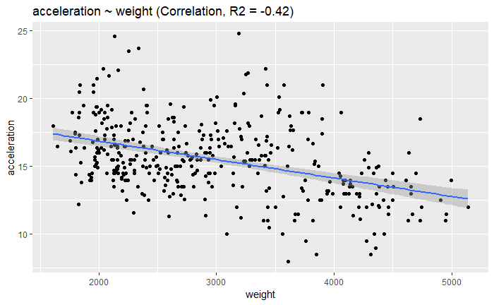

```r
library(rstan)
library(ggplot2)
library(data.table)
auto <- read.csv("http://www-bcf.usc.edu/~gareth/ISL/Auto.csv")
auto$weight_scaled <- as.vector(scale(auto$weight))
auto$acc_scaled <- as.vector(scale(auto$acceleration))
ggplot(auto, aes(x = weight, y = acceleration)) +
  geom_point() +
  geom_smooth(method = "lm") +
  ggtitle(sprintf("acceleration ~ weight (Correlation, R2 = %s)",
                  with(auto, round(cor(acceleration, weight), 2))))
```

## Outline of a Stan program

In our last notebook, we gave the following template for a Stan program with separate blocks for the `data`, `parameters` and `model`:

```
data {
  // definition of the input data here
}
parameters {
  // define the parameters here
}
model {
  // insert model here
}
```

Specifically, for our auto dataset, we defined the following model:

Which can be expressed in Stan as:

```
data {
  int<lower=0> N;   // the number of observations
  vector[N] x;      // the explanatory variable
  vector[N] y;      // the dependant variable
}
parameters {
  real alpha;
  real beta;
  real<lower=0> sigma;
}
model {
  y ~ normal(alpha + beta * x, sigma);
}
```

To include priors, we are going to extend the `model` block a little. We will still assume the same form, but we are going to write it out a little more explicitly:

$$y \sim normal(\mu, \sigma) \\
\mu = \alpha + \beta * x \\
\alpha \sim normal(0, 100) \\
\beta \sim normal(0, 10) \\
\sigma \sim cauchy(0, 1)$$

This is a little more involved, but it can be read directly:

If you can write out a model as we have above, then you can write it in Stan just as easily (just flip it upside down). The only “trick”, is that we have to define a variable `mu` and its formula. All of this gets added to the `model` block:

```r
weak_priors <- "
data{
    int<lower=1> N;
    real y[N];
    real x[N];
}
parameters{
    real alpha;
    real beta;
    real<lower=0> sigma;
}
model{
    vector[N] mu;
    sigma ~ cauchy( 0 , 1 );
    beta ~ normal( 0 , 10 );
    alpha ~ normal( 0 , 100 );

    for ( i in 1:N ) {
        mu[i] = alpha + beta * x[i];
    }

    y ~ normal( mu , sigma );
}
"
```

Hopefully, that looks nice and simple :)

## Fitting the model

Fitting the model is no different to previous. The only change I am going to make here, is that I will fit the model using the string above, rather than from a stan model file:

```r
fit01 <- stan(model_code=weak_priors,
            data = list(N = nrow(auto), x = auto$weight_scaled, y = auto$acc_scaled),
            pars = c("alpha", "beta", "sigma"),
            chains = 4, iter = 2000, algorithm = "HMC")
```

As before, let’s look at the convergence diagnostics:

```r
summary(fit01)$summary
```

```
               mean     se_mean         sd         2.5%           25%           50%          75%         97.5%
alpha   -0.01068843 0.010610792 0.04670056   -0.1030454   -0.04145899   -0.01072923    0.0216619    0.07989722
beta    -0.42085284 0.001869538 0.04429874   -0.5049848   -0.45195148   -0.42048216   -0.3892945   -0.33731733
sigma    0.90990728 0.001212154 0.03283053    0.8509876    0.88621632    0.90964433    0.9323526    0.97433113
lp__  -161.81221339 0.156146845 1.17376347 -164.8277313 -162.41692541 -161.51431721 -160.9216524 -160.40750665
          n_eff     Rhat
alpha  19.37085 1.118205
beta  561.45413 1.001038
sigma 733.56784 1.007482
lp__   56.50602 1.063490
```

We get the same (or very similar) posterior estimates for `alpha` and `beta`, which is good news. But, we still get inflatted `RHat` values on some runs of this model.

All of our results so far have been very consistent. It’s safe to say that we have quite a bit of “prior information” here that we can feed into our model. Specifically, we can be very sure that the intercept is about zero and we are pretty confident that the slope is -0.4. So, let’s pass in stronger priors. We will:

- use Gelman’s ‘default’ prior of `normal(0, 1)` for the intercept
- use an even more informative prior for `beta` and center this towards negative values

```r
informative_priors <- "
data{
    int<lower=1> N;
    real y[N];
    real x[N];
}
parameters{
    real alpha;
    real beta;
    real<lower=0> sigma;
}
model{
    vector[N] mu;
    sigma ~ cauchy( 0 , 1 );
    beta ~ normal( -0.5 , 0.5 );
    alpha ~ normal( 0 , 1 );

    for ( i in 1:N ) {
        mu[i] = alpha + beta * x[i];
    }

    y ~ normal( mu , sigma );
}
"
fit02 <- stan(model_code=informative_priors,
            data = list(N = nrow(auto), x = auto$weight_scaled, y = auto$acc_scaled),
            pars = c("alpha", "beta", "sigma"),
            chains = 4, iter = 2000, algorithm = "HMC")
summary(fit02)$summary
```

And looking at the summary output:

```r
summary(fit02)$summary
```

[output not shown]

Although I like to think that the Frequentist vs. Bayesian argument is largely moot now, quite often, the selection of “proper” priors is seen as a bit of a dark art to many frequentist statisticians. There is no doubt that we have “guided” the model towards estimates that we favour. However, given sufficient data and sufficient training time, a model will have a good chance at overcoming unreasonably restrictive (or just plain wrong) priors. Experimenting with different priors and observing the model’s sensitivity to changes in priors is common practice in Bayesian modelling. If your model is sensitive to the choice of prior, then that’s a good sign that you’ve got the form of the model wrong or there is something to be addressed in the data.

Finally, let’s look at one more common prior: the laplace prior, or a ‘lasso’ regularising prior. These are fantastic priors for introducing sparsity / bias into the model estimates, and they are particularly helpful in models with many parameters. Here, we will place a laplace prior on the `beta` estimate:

```r
laplace_priors <- "
data{
    int<lower=1> N;
    real y[N];
    real x[N];
}
parameters{
    real alpha;
    real beta;
    real<lower=0> sigma;
}
model{
    vector[N] mu;
    sigma ~ cauchy( 0 , 1 );
    beta ~ double_exponential( -0.5, 1 );
    alpha ~ normal( 0 , 1 );

    for ( i in 1:N ) {
        mu[i] = alpha + beta * x[i];
    }

    y ~ normal( mu , sigma );
}
"
fit03 <- stan(model_code=laplace_priors,
            data = list(N = nrow(auto), x = auto$weight_scaled, y = auto$acc_scaled),
            pars = c("alpha", "beta", "sigma"),
            chains = 4, iter = 10000, algorithm = "HMC")
```

Note, that I have also increased the number of samples to 10K. I’m pretty confident in this model now and if I want to make posterior inference, then more samples will give me a better perspective for inference and prediction.

```r
summary(fit03)$summary
```

```
               mean      se_mean         sd          2.5%           25%           50%           75%
alpha -7.546274e-04 0.0014341556 0.04585099   -0.08955192   -0.03154865 -5.345642e-04    0.03018009
beta  -4.207132e-01 0.0008084812 0.04612006   -0.51175472   -0.45134214 -4.208297e-01   -0.38987324
sigma  9.098996e-01 0.0006036977 0.03273578    0.84872710    0.88731659  9.088488e-01    0.93134170
lp__  -1.618808e+02 0.0234936192 1.24724815 -165.16610567 -162.44535206 -1.615496e+02 -160.96878001
              97.5%    n_eff     Rhat
alpha    0.08838397 1022.127 1.001915
beta    -0.32997210 3254.167 1.001403
sigma    0.97711606 2940.399 1.000802
lp__  -160.46075849 2818.421 1.000197
```

And again, we get consistent posterior estimates and the `Rhat` values look good. Note that I have centered the laplace prior at -0.5. If you’re interested, then try to center this at 0 instead, you should see the `Rhat` value start to deviate for the `beta` estimate.

Finally, let’s look at some posterior plots. Again, let’s look at the posterior distributions for `alpha` and `beta`:

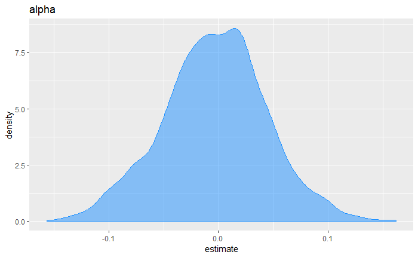

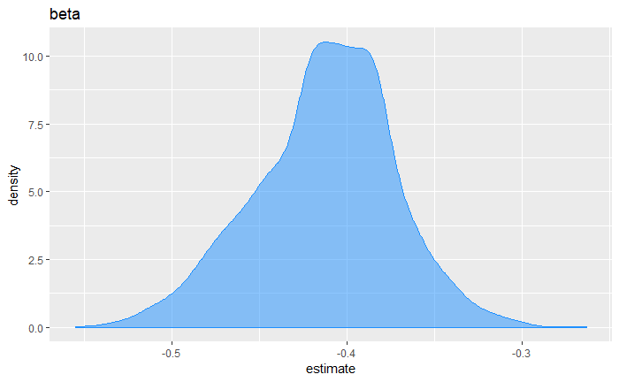

```r
for (p in c("alpha", "beta")) {
  posterior <- data.table(estimate = extract(fit, p)[[1]])

  g <- ggplot(posterior, aes(x = estimate)) +
    geom_density(colour = "dodgerblue", fill = "dodgerblue", alpha = 0.5) +
    ggtitle(p)

  print(g)
}
```

These look reasonable good. They are perhaps not quite as uniform as I’d normally expect, but that might again be due to the limited number of observations coupled with the relatively weak signal.

As before, let’s again look at posterior predictions over a range of weights:

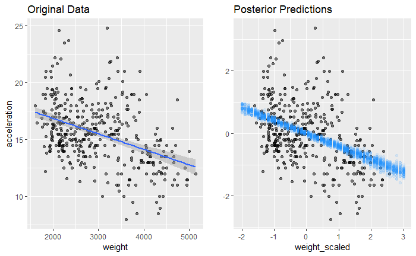

```r
posterior <- extract(fit)
weight_range <- seq(-2, 3, length.out = 50)
predictions <- rbindlist(
  lapply(weight_range, function (w) {
    tmp <- data.table(
      Weight = w,
      Acceleration = with(posterior, alpha + beta * w)
    )
  })
)
g1 <- ggplot(auto, aes(x = weight, y = acceleration)) +
  geom_point(alpha = 0.5) +
  geom_smooth(method = "lm") +
  ggtitle("Original Data")
g2 <- ggplot(auto, aes(x = weight_scaled, y = acc_scaled)) +
  geom_point(alpha = 0.5) +
  geom_point(data = predictions[sample(.N, 2000)], aes(x = Weight, y = Acceleration), colour = "dodgerblue", alpha = 0.1) +
  ylab("") +
  ggtitle("Posterior Predictions")
gridExtra::grid.arrange(g1, g2, ncol = 2)
```

Again, the posterior predictions look really, really good. :)

If this was helpful, then there is a great blog post here that explores a range of priors and includes some great plots: https://betanalpha.github.io/assets/case_studies/bayes_sparse_regression.html